# IO structure — demand channels and cross-border trade

Revised high-finance measurements beside the frozen descriptive section

## Revised structure

### Full multi-region input-output accounting

The two-region system has 54 industries per region and 108 industry outputs in total. The four intermediate-flow blocks record domestic and bilateral purchases. Household and government consumption, private net investment, replacement investment and public investment are separate final-demand channels in the revised Figure redraw. The revised figures use each high-finance credit gold arm’s unshocked baseline at $t=70$, reconstructed with the engine’s Armington-adjusted operated matrix and final-demand origin shares. Channel volumes satisfy the stored final-demand and $x-A_{arm}x-d$ accounting checks in `R/figures/plot_revised_descriptive_figures.R`.

### Demand structure and channel architecture

The table below measures each channel’s reach as a percentage of **the intervening region’s primary sector gross output**, on the EU/RoW high-finance credit gold baseline at $t=70$. It reads the same derived grid used for the Figures tab. The original section’s 93–96% claim for cement, glass, metals and pulp does not hold on this basis: their intermediate reaches differ substantially. Food’s household channel remains the largest, fossil energy is predominantly intermediate, and government procurement remains unusually large for plastics. These are channel shares of primary-sector output; they are not shares of all final demand or of both regions’ output.

|  | Material | Households (% primary output) | Government (% primary output) | Intermediate (% primary output) | All final demand (% primary output) |
| --- | --- | --- | --- | --- | --- |
| Cement | Cement | 1.0 | 0.2 | 95.2 | 2.3 |
| Glass | Glass | 0.9 | 0.2 | 79.8 | 2.0 |
| Metals | Metals | 1.5 | 0.2 | 78.4 | 2.7 |
| Pulp | Pulp | 1.8 | 0.6 | 85.9 | 3.4 |
| Food | Food | 63.2 | 0.2 | 27.1 | 63.6 |
| Energy | Energy | 31.5 | 0.2 | 64.3 | 35.3 |
| Plastics | Plastics | 4.8 | 47.6 | 41.6 | 53.4 |

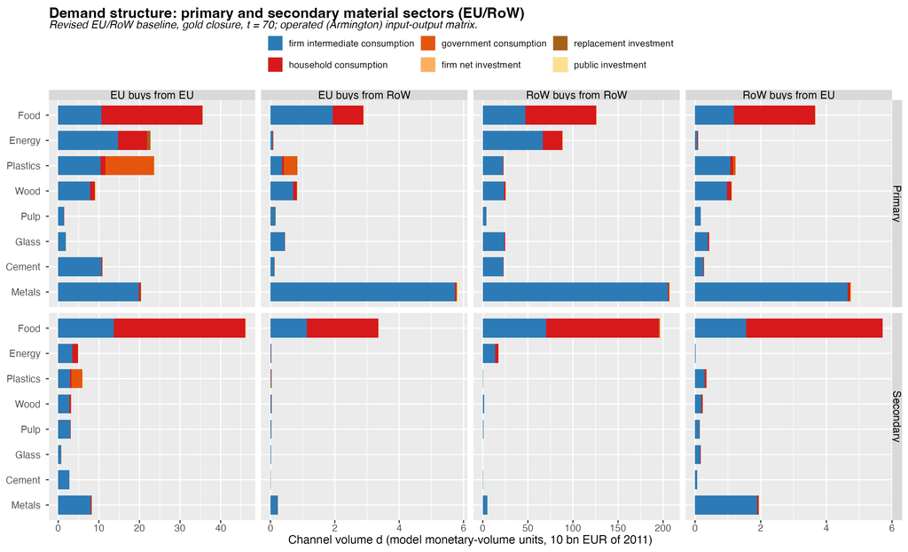

### Cross-border trade structure

The import figure shows EU purchases from RoW, ranked by total channel volume across the 54 supplier industries, on the same baseline and operated matrix. The upstream figure displays $L-I$ for the intervening region’s primary-material columns. These are model monetary-volume requirements per unit of final demand, not a physical footprint. The figures support comparisons of channels and suppliers; a claim that any one channel causes a dynamic current-account or employment response requires the matched scenario runs in the cross-border Figures.

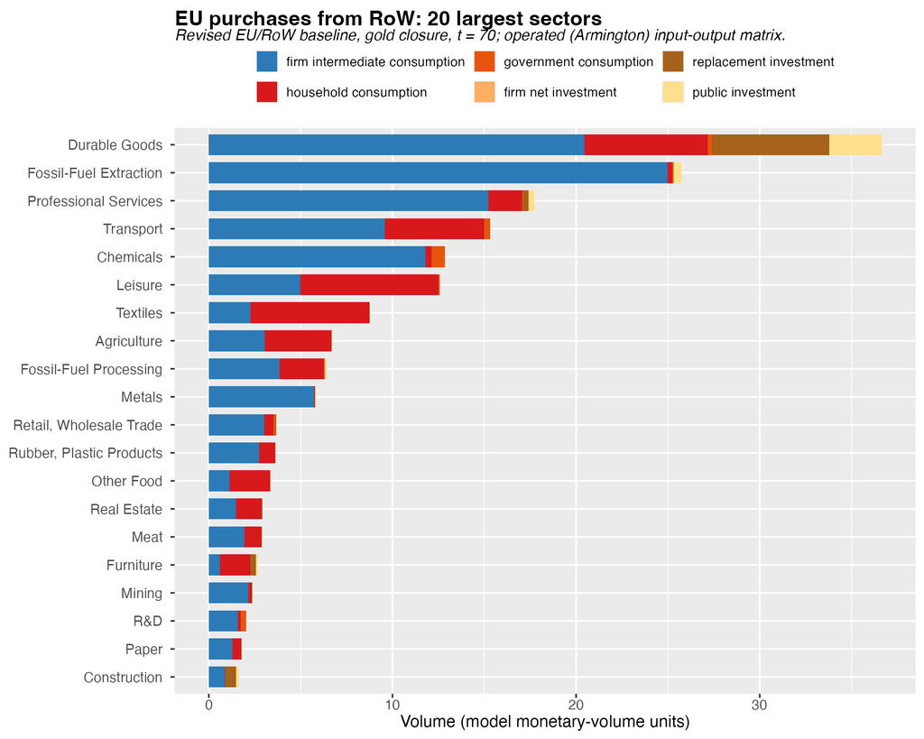

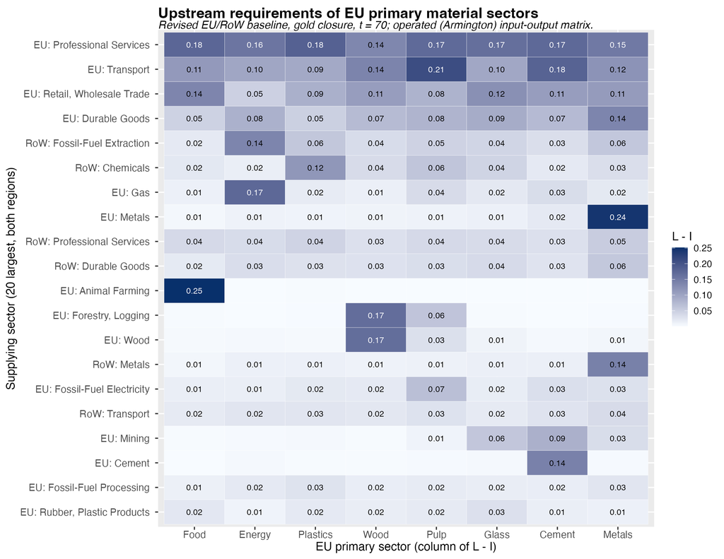

The Figures tab lets the reader switch between the EU/RoW and North/South redraws. The Scenario design page derives how the channel scale enters the first-order impact.

### Submitted measurements against the revised basis

The comparison below follows each numerical claim in the submitted Demand Structure paragraph. Revised shares are read from the high-finance EU/RoW gold baseline’s `descriptive_grids` file, which the Figures redraw generated from the operated Armington matrix at t = 70. Each denominator is the gross output of the EU primary sector named in the row. The submitted text uses its own April 2026 calibration; the two columns are different experiments.

| Submitted sentence | Revised high-finance EU/RoW, % of primary output |
| --- | --- |
| Cement, glass, metals and pulp: intermediate use 93–96% | cement 95.2%; glass 79.8%; metals 78.4%; pulp 85.9% |
| Food: household consumption 65% | 63.2% |
| Energy: intermediate procurement about two thirds | 64.3% |
| Plastics: final demand about 55% | 53.4% |

## Submitted text (2026-04-03)

The following prose and equations are copied from the frozen Descriptive Statistics section. Its figure references and empirical claims refer to the submitted calibration. The submitted executable figure and table chunks are represented by the revised images and channel table above.

## Descriptive Statistics: the EU-RoW Input-Output Structure of Demand

This section documents the complex multi-region input-output (MRIO) structure of demand for ten key material pairs in the EU and Rest of World (RoW), as calibrated in the model at its baseline at $t = 70$. Its purpose is to establish the structural features of demand — channel scale and cross-border trade flows — that directly anticipate the simulation results. Because the structural Leontief factor $(l_{12} - l_{11}) \approx -1$ across all material pairs, the ranking of CE interventions by ecological impact reduces to a ranking of channel volumes, which the figures below measure directly.

### Full Multi-Region Input-Output Accounting

At the core of the production block is a two-region, 108-sector MRIO system. An MRIO table extends the standard national input-output framework by tracking both inter-industry transactions within each region and cross-border trade flows between regions. Table 1 summarises the full accounting structure. Reading across the rows, the table shows where the output of each region is sold: to other industries as intermediate inputs (the $Z$ blocks), or to final users as consumption, government, or investment. Reading down the columns, it shows what each industry or final-demand category purchases: intermediate inputs from either region, and primary factor payments (wages, profits, taxes) constituting value added. The double-entry structure enforces a fundamental balance: total output for each region equals total intermediate sales plus total final demand sales, and simultaneously equals total intermediate purchases plus total value added.

Concretely, the intermediate demand block consists of four sub-matrices: domestic intermediate flows ($Z_{EU,EU}$, $Z_{RoW,RoW}$) and cross-border flows ($Z_{EU,RoW}$, $Z_{RoW,EU}$). The final demand block disaggregates by institutional channel (household consumption $c$, government consumption $g$, and private investment $id$) and by spending region, so that every cell reflects both a sourcing region and a spending region — the bilateral structure essential for tracing how CE policy shocks propagate across borders. Value added is recorded below the intermediate block, and column sums equal total gross output by sector.

**Multi-region input-output equilibrium in supply and demand** can be written as the $\mathbf{x} \in \mathbb{R}^{RN \times 1}$ supply or gross output vector equals the sum of intermediate demand $Z \in \mathbb{R}^{RN \times RN}$ and final demand $Y \in \mathbb{R}^{RN \times RK}$, with $R = \{EU,RoW\} = 2$ regions, $N=54$ sectors, and $K = \{c,g,id\} = 3$ institutional channels:

$$\begin{aligned}
\begin{pmatrix}\mathbf{x}_{(1)}\\\mathbf{x}_{(2)}\end{pmatrix} &= \mathbf{x} = \mathbf{d} = Z + Y =
\underbrace{\begin{pmatrix}Z_{11} & Z_{12}\\Z_{21} & Z_{22}\end{pmatrix}}_{\text{intermediate demand}}
+ \underbrace{\begin{pmatrix}C_1\\C_2\end{pmatrix}}_{\text{HH cons.}}
+ \underbrace{\begin{pmatrix}G_1\\G_2\end{pmatrix}}_{\text{Govt.}}
+ \underbrace{\begin{pmatrix}I_1\\I_2\end{pmatrix}}_{\text{Firm inv.}} =\\[8pt]
&= \underbrace{\begin{pmatrix}A_{11} & A_{12}\\A_{21} & A_{22}\end{pmatrix}}_{A\;=\;Z\hat{x}^{-1}}
\begin{pmatrix}\mathbf{x}_{(1)}\\\mathbf{x}_{(2)}\end{pmatrix}
+\underbrace{\begin{pmatrix}\boldsymbol{\beta}_{11} & \boldsymbol{\beta}_{12}\\\boldsymbol{\beta}_{21} & \boldsymbol{\beta}_{22}\end{pmatrix}}_{B\;\in\;\mathbb{R}^{RN\times R}}
\begin{pmatrix}c_1\\c_2\end{pmatrix}
+\underbrace{\begin{pmatrix}\boldsymbol{\sigma}_{11} & \boldsymbol{\sigma}_{12}\\\boldsymbol{\sigma}_{21} & \boldsymbol{\sigma}_{22}\end{pmatrix}}_{\Sigma\;\in\;\mathbb{R}^{RN\times R}}
\begin{pmatrix}g_1\\g_2\end{pmatrix}
+\underbrace{\begin{pmatrix}\boldsymbol{\iota}_{11} & \boldsymbol{\iota}_{12}\\\boldsymbol{\iota}_{21} & \boldsymbol{\iota}_{22}\end{pmatrix}}_{I\;\in\;\mathbb{R}^{RN\times R}}
\begin{pmatrix}id_1\\id_2\end{pmatrix} =\\[8pt]
&= A\mathbf{x} + \underbrace{\begin{pmatrix}B & \Sigma & I\end{pmatrix}}_{\boldsymbol{\Phi}\;\in\;\mathbb{R}^{RN\times RK}} \operatorname{vec}
\underbrace{\begin{pmatrix}c_1 & g_1 & id_1 \\ c_2 & g_2 & id_2\end{pmatrix}}_{\mathbf{F}\;\in\;\mathbb{R}^{R\times K}}
= A\mathbf{x} + \boldsymbol{\Phi}\,\mathbf{f} =\\[8pt]
&= \underbrace{\sum_{s,j} a_{ri,sj}\, x_{sj}}_{\text{intermediate demand}}
+ \underbrace{\sum_{r=1}^{R} \left(\boldsymbol{\beta}_{(r)}\, c_r + \boldsymbol{\sigma}_{(r)}\, g_r + \boldsymbol{\iota}_{(r)}\, id_r\right)}_{\text{final demand}}
= \sum_{s,j} a_{ri,sj}\, x_{sj}
+ \sum_{r=1}^{R}\sum_{k=1}^{K} \phi_{r,k}\, f_{r,k}
\end{aligned} \tag{2.1}$$

where

- $Z_{sr}\in\mathbb{R}^{N\times N}$ is the intermediate flow matrix from supplying region $s$ to demanding region $r$,
- $A_{rs}=Z_{sr}\hat{x}_r^{-1}$ is the $RN \times RN$ matrix of multi-region input-output coefficients $a_{si,rj}$,
- $B = \begin{pmatrix}\boldsymbol{\beta}_{11} & \boldsymbol{\beta}_{12}\\\boldsymbol{\beta}_{21} & \boldsymbol{\beta}_{22}\end{pmatrix}\in\mathbb{R}^{RN\times R}$ is the block matrix of column-vector components $\beta_{si,r}$, the household consumption share demanded by region $r$ and supplied by industry $i$ in region $s$; $\Sigma$ and $I$ follow the same structure for government spending and firm investment,
- $\mathbf{f} = \operatorname{vec}(\mathbf{F}) \in\mathbb{R}^{RK\times1}$ stacks the $R\times K$ final demand expenditure matrix $\mathbf{F}$ by region $r$ and institutional channel $k \in \{c,\,i,\,g\}$ (household consumption, firm investment, government spending),
- $\boldsymbol{\Phi}=(B\;\Sigma\;I)\in\mathbb{R}^{RN\times RK}$ is the final demand share matrix, with entry $\phi_{si,r,k}$ the share of channel-$k$ spending of region $r$ sourced from industry $i$ in region $s$,
- $\boldsymbol{\Omega} = \boldsymbol{\Phi}\,\mathbf{f} \in\mathbb{R}^{RN\times1}$ is the final demand volume vector — the sectoral allocation of aggregate expenditure across all channels and regions.

The full MRIO Leontief solution is:

$$\mathbf{x} = (I - A)^{-1}\,\boldsymbol{\Phi}\,\mathbf{f} = L\,\boldsymbol{\Phi}\,\mathbf{f} = L\,\boldsymbol{\Omega} \tag{2.2}$$